# Using Bin Design and Planned behaviour to Improve Recycling participation

Joseph Cotton ECON - 390 Xavier University

11 - 14 - 2022

**Executive Summary:** While a lot of progress has been made in altering institutional processes, reinforcing recycling habits at the residential level has been challenging due to the messiness of human behaviour and psychology. We propose that behavioural nudges can be used to reinforce recycling habits and minimize residential recyclables that end up in the landfill. Both increasing the size of the recycling bin and prompting people to make a household recycling should improve residential diversion rates.

[figure not shown]

## Increasing household recycling participation

Increasing solid waste diversion rates requires both institutional support and changes in consumer behaviour. While a lot of progress has been made in altering institutional processes, reinforcing recycling habits have been challenging due to the messiness of human behaviour and psychology.

When examining margins of improvement for participation in recycling programs, two areas of concern come to mind: increasing the amount of recyclables that end up in the recycling bin (diversion) and decreasing the amount of non-recyclables that end up in the recycling bin (contamination).

Within Hamilton county, Cincinnati lags behind other cities with a diversion rate of 20% (Buch et al., 2015). The best city in Hamilton county, Mariemont, has a diversion rate of 66%. While people often chalk this disparity up to cultural differences, most other countries have a recycling infrastructure that makes it easier for the end consumer to recycle products in both residential and public settings.

When recycling containers are contaminated, the financial outlook of the recycling program is negatively impacted. Contamination represents both additional expenses in transportation and processing and lowers the yield quality and quantity of recycled materials (Miller, 2021). This dynamic has become increasingly the case as traditional buyers of American recycled material, such as China, have become pickier about the purity of materials purchased (Joyce, 2019).

When designing a intervention to increase diversion rates, two things need to be kept in mind. The first is that more preferred choice should be made as easy to execute as possible. The second is that any intervention that is too heavy handed will place an inequitable burden upon low-income households.” On the Green Cincinnati Plan (GCP) website under *Waste* and *Recommendation* it reads, “1) Increase cost of trash generation to encourage diversion from landfill.” (www.cincinnati-oh.gov). Increasing the cost of trash generation through a tax or fee of some sort without making it easier to recycle will place an undue pressure on low-income households without improving recycling rates.

To achieve the goals laid out in the GCP, a series of well structured nudges can potential make substantial improvements without the need for expensive interventions or heavy handed financial incentives. The first nudge is making the recycling bin larger compared to the trash bin. This change will give the impression that recycling is more important than the trash bin. The second nudge is prompting people to make a recycling plan that works for their household.

## Design & Planned behaviour Nudges

We can improve diversion rates and decrease contamination in recyclables by implementing a set of nudges. Whenever waste bins are replaced in a residential setting we can give them a **proportionally larger recycling bin** and a **handout which prompt them to create a recycling plan that works for them**. We can also add some literature that highlights the importance of recycling.

Both of these nudges would impact the “recycling/composting” tier of the Waste Management Hierarchy and the household recycling plan would impact the top “source reduction and reuse” tier.

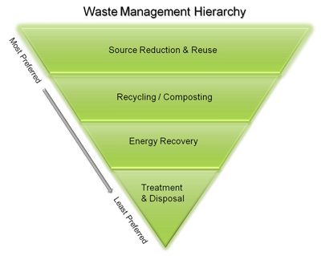

### Increasing the relative size of recycling bins

Currently, trash bins and recycling bins that are given to residential single family households are the same size. When these two bins are the same size, it sends the signal that both of the bins require the same amount of mental effort. By increasing the relative size of recycling bins (either increasing the size the size of recycling bins or decreasing the size of trash bins), we would be sending a signal that recycling should be prioritized. Because bins are often replace by the city and Rumpkee, it would be easy to give each household a slightly larger bin when they need one.

This nudge would help with increase diversion rates by having people put more effort into filling up a larger recycling bin and ensuring that all the non-recyclable waste fits in the smaller trash bin. While not directly supported in the academic literature, it is possible that the effect may be achieved by changing the dimensions of the bin to create an illusion of increased size if cost is prohibitive (Labbe et al., 2018).

### Prompting households to make a recycling plan

Because every household is different, it is hard to make general recommendations to encourage households to recycle. Furthermore, top-down recommendation are easily ignored because there is no mental ownership over the actions that are suggested.

To address both of these challenges, we could implement a planned behaviour nudge that would encourage people to make a structured recycling plan tailored around their specific household needs. This nudge could simply be a handout that prompts people to write out a plan that about how they will manage waste and reduce the amount of waste that they create. I could also be a QR code that directs people to a website with prompts and inspiration ideas around sustainability. This nudge could either be used on its own by putting the messaging on the recycling bins when they are replaced or it could also be added to other interventions in the waste management space. Incentives could also be attached to the program to encourage people to fill out the plan. For example, signage for the front door, being featured on city social media platforms or even a cash sweepstakes.

This nudge would help with the problem of contamination by nudging people into executing a previously established plan thus making their waste management behaviours more intentional. It would also help with increasing diversion rates by taking out the cognitive cost of making a decision when waste needs to be taken care of.

## Theoretical Framework: Theory of Planned Behaviour

According to the Theory of Planned Behaviour, Their are three factors that influence intentions that turn into behaviours (Ajzen, 1985).

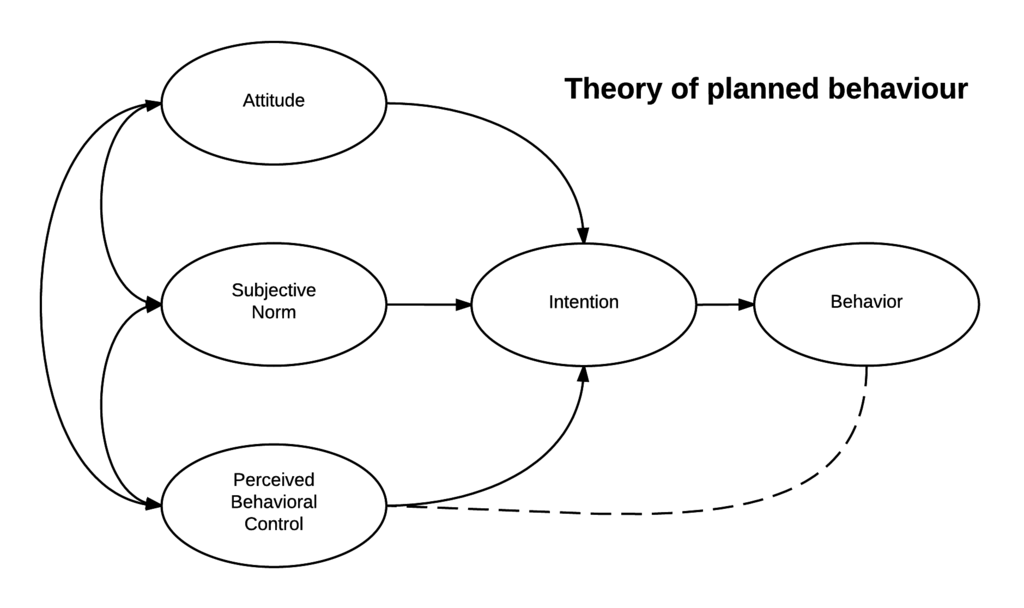

Robert Orzanna - Own work, CC BY-SA 4.0

The first is the persons positive and/or negative *attitude* towards the behaviour in question. The most classic example is the individuals attitude towards a product they are buying. If people feel as though they will experience some benefit through purchase of the product, they are more likely to make a purchase. For our purposes, we can assume that most people have a generally positive attitude towards sustainability and will see recycling as a net positive.

The second factor is the persons *subjective norm*. This refers to the belief that people hold regarding the social norms surrounding the behaviour. In marketing, online retailers will highlight the reviews of a product to reinforce the belief that a majority of people find the product to be useful or socially desirable in some regard. In the case of recycling, the subjective norm is how people perceive others attitudes towards recycling and other sustainable behaviours.

The subjective norm is the avenue by which altering the dimensions of the recycling bin could work to increase diversion rates. In behavioural theory, this is refereed to as a social norm nudge. The classic example of a social norm nudge is showing household the amount of energy they use compared to their neighbors to lower energy expenditures (Schultz et al., 2007). Implementing a similar nudge in the case of recycling, however, has been shown to be counter productive (Czajkowski et al., 2019). The underwhelming effectiveness of this nudge is likely due to an “out-of-reach” effect which sees people continue existing behaviour because they don’t believe they have the ability to change it. Though not strictly a social norm nudge, we can implement a similar strategy without unintended effects by giving each household a relatively larger bin. By increasing the relative size of the recycling bin, we are gently prompting households to change their behaviour to conform to the social norm that the design implies (Lane & Wagner, 2013). In theory, households would both increase their effort both to fill-up the recycling bin and to keep recyclables out of the trash bin in order to avoid needing an extra bin. Additionally, human attention has been shown to quickly notice discrepancies in size (Proulx, 2010). By changing the bin proportions, we can draw attention to the recycling bin and make the thought of sorting behaviour more cognitively available.

The final factor in the theory of planned behaviour is *perceived behavioural control* (PBC). The recycling plan nudge works on altering a persons perceived behavioural control by having them create a plan that they can easily execute. One of the most recent examples of PBC nudges is in regards to voting behaviour. Because voting requires the upfront cost of researching candidates, polling locations, etc., prompting people people to make a plan when they have free time to do so allows them to simply execute the plan that they made on election day (Rogers et al., 2015). Prompting people to make a recycling plan would increase peoples PBC by allowing them to breakdown the sub-habits of recycling and making the behaviour seem easier to execute.

# Proof of concept

This section is designed to highlight different pieces of academic literature that support the nudge interventions of increase recycling bin size and prompts to create a household recycling plan.

## Increase recycling bin size.

Increasing the size of the recycling bin would work by creating a implicit social norm that encourages people to pay more attention to their recycling behaviour. This phenomena, called a visual consumption norm, has been shown to change peoples behaviour, particularly when it comes to the consumption of food.

It can then be posited that changing the relative size of the recycling bins that are provided to households could have a similar effect of setting a different social norm for recycling behaviour. A bigger recycling bin compared to a smaller trash bin would imply that more attention needs to be paid to filling up the recycling bin compared to trash bin.

There is limited research on how bin size impacts recycling behaviour. The research that is out there is inconclusive. In *Examining recycling container attributes and household recycling practices* (Lane & Wagner, 2013), the authors examine a survey of 784 municipal recycling programs. Their research involved looking at several design elements, including bin size, and whether or not they had any impact on municipal diversion rates. The study found a positive relationship between municipalities with larger recycling bins and better recycling rates, however, the results were not significant. While this result could be interpreted to support the assumption that bin size does not impact recycling behaviour, this study is not directly applicable to evaluating the effectiveness of the proposed nudge. For one, the study did not examine *relative* bin size which is the main vector which the nudge is designed to impact behaviour. Additionally, the study did not look at municipalities before and after they changed their bin size.

As opposed to bin size, other design elements of recycling bins have been shown to impact the recycling behaviour in the academic literature. In *The effect of recycling bin design on PET bottle collection performance* (Jiang et al., 2019), researchers placed plastic bottles (PET) of various designs around the Suzukakedai campus of Tokyo Technical university. The researchers wanted to discover what recycling designs would encourage more bottle and cap separation and decrease the amount of contamination in the bins. These designs varied across the shape of the insert slot, the amount of signage that was placed on the bin, whether or not the bins were placed next to other waste management bins and the whether or not there were two separate bins for bottles and caps.

They also show that there was a large disparity between what people stated was their preferred design in surveys and what design actually led to the better separation behaviour and lower contamination levels.

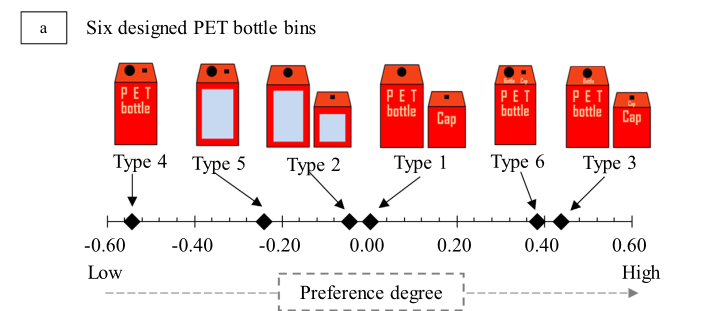

Bin Preference based on survey

While **type 3** was the most preferred design in the preliminary research questionnaire, it actually performed worse than the **type 4** bin design which was both the least preferred bin design and the best performing one. These results highlight the importance of relying on empirical data instead of the input of the public when implementing a design that is used to change macro-behaviour. The authors research suggests that all-in-one bin design, round shaped insert slots and large recycling signage had the biggest impact on both separation rates and contamination of the recycling bin.

## Creating a recycling plan.

Planned behaviour nudges have a large body of academic literature supporting their effectiveness. One of the most cited examples of this kind of nudge is *Using implementation intentions prompts to enhance influenza vaccination rates* (Milkman et al., 2011). In this article, the researchers split groups into three different categories and adjusted the types of messaging they received reminding them to get a dose of the influenza vaccine. The control group was given a generic reminder. The second group was given a prompt to write down the time they would receive the vaccine and the last group was prompted to put down the time and the date. The researchers found that the participants that were placed in the third group were 4.2 percent more likely to follow through with their plan to receive the vaccine.

Another area which the planned behaviour nudging has shown to be effective is in the area of diet adherence. In the paper, *Implementation Intentions and Shielding Goal Striving From Unwanted Thoughts and Feelings* (Achtziger et al., 2008), the authors look at how planned behaviour can improve the participants desired performance vector. In the study, participants were placed into three separate groups. The first group was not prompted to create a specific goal. The second group was prompted to make a goal intention. The third treatment group was prompted to make an implementation intention that had them create different “if-then” plans to deal with situations that would make it more difficult for them to adhere to the goal. The base prompt reads,*“If situation X arises, then I will do Y!”* They ran the study twice; in the first study, the intention of the participants was to eat healthier and in the second study, the intention was to improve sports performance by controlling their mental state.

Planned behaviour has been shown to also positively impact people’s recycling behaviour. In the paper, *Breaking and creating habits on the working floor: A field-experiment on the power of implementation intentions* (Holland et al., 2006), the authors look at how planned behaviour cold impact habit creation. In the study, participants in an office building were placed into three separate groups. The control group was given no intervention. The second group was exposed to “eye-catching” signage which was placed around the office to promote recycling. The third treatment group was prompted to make an implementation intention plan that would organize their actions both before and after consuming a waste product (i.e paper, plastic cups etc.) The study found that the participants in the treatment group that received the planned behaviour nudge were both more likely to reduce their use of both paper and plastic cups and to recycle them when they were used.

# Works cited

Achtziger, A., Gollwitzer, P. M., & Sheeran, P. (2008). Implementation intentions and shielding goal striving from unwanted thoughts and feelings. *Personality and Social Psychology Bulletin*, *34*(3), 381–393. https://doi.org/10.1177/0146167207311201

Ajzen, I. (1985). From intentions to actions: A theory of planned behavior. In J. Kuhl & J. Beckmann (Eds.), *Action control: From cognition to behavior* (pp. 11–39). Springer Berlin Heidelberg. https://doi.org/10.1007/978-3-642-69746-3_2

Czajkowski, M., Zagórska, K., & Hanley, N. (2019). Social norm nudging and preferences for household recycling. *Resource and Energy Economics*, *58*, 101110. https://doi.org/https://doi.org/10.1016/j.reseneeco.2019.07.004

Holland, R. W., Aarts, H., & Langendam, D. (2006). Breaking and creating habits on the working floor: A field-experiment on the power of implementation intentions. *Journal of Experimental Social Psychology*, *42*(6), 776–783. https://doi.org/https://doi.org/10.1016/j.jesp.2005.11.006

Jiang, Q., Izumi, T., Yoshida, H., Dilixiati, D., Leeabai, N., Suzuki, S., & Takahashi, F. (2019). The effect of recycling bin design on PET bottle collection performance. *Waste Management*, *95*, 32–42. https://doi.org/https://doi.org/10.1016/j.wasman.2019.05.054

Joyce, C. (2019). U.s. Recycling industry is struggling to figure out a future without china. In *NPR*. NPR. https://www.npr.org/2019/08/20/750864036/u-s-recycling-industry-is-struggling-to-figure-out-a-future-without-china

Kurz, T., Gardner, B., Verplanken, B., & Abraham, C. (2015). Habitual behaviors or patterns of practice? Explaining and changing repetitive climate-relevant actions. *WIREs Climate Change*, *6*(1), 113–128. https://doi.org/https://doi.org/10.1002/wcc.327

Labbe, D., R. Fries, L., Ferrage, A., Lenfant, F., Godinot, N., & Martin, N. (2018). Right sizing: Sensory-based product design is a promising strategy to nudge consumers toward healthier portions. *Nutrients*, *10*(10). https://doi.org/10.3390/nu10101544

Lane, G. W. S., & Wagner, T. P. (2013). Examining recycling container attributes and household recycling practices. *Resources, Conservation and Recycling*, *75*, 32–40. https://doi.org/https://doi.org/10.1016/j.resconrec.2013.03.005

Milkman, K. L., Beshears, J., Choi, J. J., Laibson, D., & Madrian, B. C. (2011). Using implementation intentions prompts to enhance influenza vaccination rates. *Proceedings of the National Academy of Sciences of the United States of America*, *108*(26), 10415–10420. http://www.jstor.org/stable/27978628

Miller, R. (2021). Contamination in recycling costs businesses money. In *Miller Recycling*. https://millerrecycling.com/recycling-contamination-costs-money/

Proulx, M. J. (2010). Size matters: Large objects capture attention in visual search. *PloS One*, *5*(12), e15293.

Rogers, T., Milkman, K. L., John, L. K., & Norton, M. I. (2015). Beyond good intentions: Prompting people to make plans improves follow-through on important tasks. *Behavioral Science & Policy*, *1*(2), 33–41.

Schultz, P. W., Nolan, J. M., Cialdini, R. B., Goldstein, N. J., & Griskevicius, V. (2007). The constructive, destructive, and reconstructive power of social norms. *Psychological Science*, *18*(5), 429–434.